# Linear Discriminant Analysis (LDA) in R

Created By Julio SOLANO

Oct 20, 2018

# Setup

```r
 set.seed(1235)
```

# Loading Libraries

```r
library(MASS)                       # lda, ldahist functions
library(MVN)                        # mvn: outliers multi-variable, normalidad multi-variable
library(caret)                      # confusionMatrix, train functions
library(PerformanceAnalytics)       # chart.Correlation function
library(klaR)                       # partimat function (final plot)
library(kableExtra)


# Organizing Packge information for table
packages <- c("MASS", "MVN", "caret", "PerformanceAnalytics", "klaR", "kableExtra")
display <- c("Package","Title", "Maintainer", "Version", "URL")
table <- matrix(NA, 1, NROW(display), dimnames = list(1, display))
for(i in 1:NROW(packages)){
list <- packageDescription(packages[i])
table <- rbind(table, matrix(unlist(list[c(display)]), 1, NROW(display), byrow = T))
}
table[,NROW(display)] <- stringr::str_extract(table[,NROW(display)], ".+,")

# Table of packages
kable(table[-1,], format = "html", align = "c") %>%
  kable_styling(bootstrap_options = c("striped", "hover", "condensed"))
```

|  | Package | Title | Maintainer | Version | URL |
| --- | --- | --- | --- | --- | --- |
|  | MASS | Support Functions and Datasets for Venables and Ripley’s MASS | Brian Ripley <ripley@stats.ox.ac.uk>; | 7.3-50 | NA |
|  | MVN | Multivariate Normality Tests | Selcuk Korkmaz <selcukorkmaz@gmail.com>; | 5.4 | NA |
|  | caret | Classification and Regression Training | Max Kuhn <mxkuhn@gmail.com>; | 6.0-80 | NA |
|  | PerformanceAnalytics | Econometric Tools for Performance and Risk Analysis | Brian G. Peterson <brian@braverock.com>; | 1.5.2 | NA |
|  | klaR | Classification and Visualization | Uwe Ligges <ligges@statistik.tu-dortmund.de>; | 0.6-14 | NA |
|  | kableExtra | Construct Complex Table with ‘kable’ and Pipe Syntax | Hao Zhu <haozhu233@gmail.com>; | 0.9.0 | http://haozhu233.github.io/kableExtra/, |

# Problem Definition

En el siguiente ejercicio trataremos el análisis discriminante. El análisis de clusters y el análisis discriminante son métodos de clasificación de individuos en categorías. La diferencia principal entre ellos escriba en que en el análisis discriminante se conoce a priori el grupo de pertenencia, mientras que el análisis de cluster sirve para formar grupos (conglomerados, clusters, racimos, etc.) lo mas homogéneos posibles.

El objetivo esencial del análisis discriminantelineal es utilizar los valores previamente conocidos de las variables independientes para predecir en qué categoría de la variable dependiente corresponde. A veces el análisis discriminante se conoce en ocasiones como análisis de la clasificación, ya que define una regla o esquema de clasificación que permita predecir la población a la que es más probable que tenga que pertenecer una nueva observación. Es decir asignar nuevos individuos al grupo que mejor corresponde en una clasificación ya establecida, construida a partir de individuos distintos. Por otro lado, la importancia de este método reside en que haciendo un análisis previo de la discriminación de las variables podemos evitar medir mas variables en el campo, analizar mas elementos, etc., y conseguir una correcta clasificación.

# Data Source

```r
metalicos <- read.csv("metalicos.csv", header = T, skip = ",")
metalicos$Group <- as.factor(metalicos$Group)
str(metalicos)                                                             # estructura del dataframe
```

```
## 'data.frame':    40 obs. of  14 variables:
##  $ Ti   : int  7280 10300 6500 7000 5100 10600 14200 9700 2300 12100 ...
##  $ Mn   : int  1300 1200 700 1500 1000 2100 2000 900 1500 6300 ...
##  $ Ag   : num  30 0.7 1 0.7 0.5 0.3 0.2 0.2 0.2 0.1 ...
##  $ Ba   : int  720 1280 1070 760 740 980 690 680 710 1520 ...
##  $ Co   : int  30 20 20 30 20 30 30 35 5 30 ...
##  $ Cr   : int  150 160 200 160 140 50 70 70 110 30 ...
##  $ Cu   : int  73 25 48 70 39 25 25 38 50 24 ...
##  $ Ni   : int  50 50 70 40 50 30 50 30 20 30 ...
##  $ Pb   : int  70 70 100 110 80 70 60 70 70 80 ...
##  $ Sr   : int  60 90 210 240 50 150 160 80 80 320 ...
##  $ V    : int  70 50 50 40 60 160 70 110 30 160 ...
##  $ Zn   : int  190 50 170 250 130 110 180 250 120 190 ...
##  $ Au   : num  0.02 0.02 0.01 0.01 0.02 0.01 0.01 0.01 0.01 0.02 ...
##  $ Group: Factor w/ 2 levels "1","2": 1 1 1 1 1 1 1 1 1 1 ...
```

```r
# Balance de Grupos
table(metalicos$Group)
```

```
##
##  1  2
## 20 20
```

```r
X <- metalicos[, -14]
```

# New Data to Classifier

```r
clasificar <- read.csv("clasificar.csv", header = T, skip = ",")
clasificar$Group <- as.factor(clasificar$Group)
str(clasificar)                                                          # estructura del dataframe
```

```
## 'data.frame':    6 obs. of  14 variables:
##  $ Ti   : int  4260 6500 12200 1080 3820 1020
##  $ Mn   : int  800 1200 5200 1600 500 2400
##  $ Ag   : num  0.3 0.5 1.5 0.2 0.2 0.1
##  $ Ba   : int  180 380 630 80 170 20
##  $ Co   : int  20 30 25 5 25 0
##  $ Cr   : int  60 40 80 10 40 10
##  $ Cu   : int  128 72 39 102 60 28
##  $ Ni   : int  30 50 40 0 20 0
##  $ Pb   : int  30 20 90 10 10 0
##  $ Sr   : int  460 320 210 160 1100 1320
##  $ V    : int  110 90 200 30 160 20
##  $ Zn   : int  80 160 180 80 40 60
##  $ Au   : num  0.02 0.01 0.01 0 0.02 0
##  $ Group: Factor w/ 1 level "9": 1 1 1 1 1 1
```

# Matriz de Correlacion

```r
cor(X, method = "spearman", use = "complete.obs")
```

```
##            Ti         Mn         Ag          Ba         Co           Cr
## Ti  1.0000000  0.7146101  0.6875189  0.71892614  0.8693991  0.562662113
## Mn  0.7146101  1.0000000  0.5430169  0.58522481  0.5960246  0.275157240
## Ag  0.6875189  0.5430169  1.0000000  0.58113166  0.7015607  0.585361338
## Ba  0.7189261  0.5852248  0.5811317  1.00000000  0.5560135  0.668344995
## Co  0.8693991  0.5960246  0.7015607  0.55601347  1.0000000  0.543711234
## Cr  0.5626621  0.2751572  0.5853613  0.66834500  0.5437112  1.000000000
## Cu -0.5568023 -0.6677727 -0.2994280 -0.40601221 -0.4429489 -0.191298991
## Ni  0.6268749  0.4828474  0.5148757  0.66235942  0.4155533  0.597790860
## Pb  0.6435933  0.6211403  0.6389884  0.73445137  0.5409683  0.611734279
## Sr -0.4647987 -0.6516611 -0.5498616 -0.52207195 -0.5002504 -0.571891717
## V   0.3537569  0.1410572  0.3066452  0.02801938  0.5088819  0.006743238
## Zn  0.5715448  0.5186684  0.2911442  0.58655058  0.5273093  0.437644685
## Au  0.2632003  0.2123835  0.2864955  0.30561886  0.2744403  0.307627763
##             Cu          Ni          Pb         Sr            V          Zn
## Ti -0.55680230  0.62687491  0.64359325 -0.4647987  0.353756945  0.57154479
## Mn -0.66777269  0.48284744  0.62114029 -0.6516611  0.141057213  0.51866842
## Ag -0.29942800  0.51487567  0.63898839 -0.5498616  0.306645209  0.29114416
## Ba -0.40601221  0.66235942  0.73445137 -0.5220719  0.028019383  0.58655058
## Co -0.44294895  0.41555335  0.54096829 -0.5002504  0.508881917  0.52730931
## Cr -0.19129899  0.59779086  0.61173428 -0.5718917  0.006743238  0.43764469
## Cu  1.00000000 -0.25246995 -0.37895879  0.4739808 -0.099722641 -0.21213446
## Ni -0.25246995  1.00000000  0.56353303 -0.4637664 -0.068602529  0.40061526
## Pb -0.37895879  0.56353303  1.00000000 -0.6442750 -0.067451773  0.43681952
## Sr  0.47398085 -0.46376641 -0.64427499  1.0000000  0.083157102 -0.41040096
## V  -0.09972264 -0.06860253 -0.06745177  0.0831571  1.000000000  0.03269423
## Zn -0.21213446  0.40061526  0.43681952 -0.4104010  0.032694229  1.00000000
## Au -0.30712462 -0.01415549  0.41819565 -0.3332415 -0.093035385  0.05695345
##             Au
## Ti  0.26320034
## Mn  0.21238354
## Ag  0.28649554
## Ba  0.30561886
## Co  0.27444025
## Cr  0.30762776
## Cu -0.30712462
## Ni -0.01415549
## Pb  0.41819565
## Sr -0.33324146
## V  -0.09303538
## Zn  0.05695345
## Au  1.00000000
```

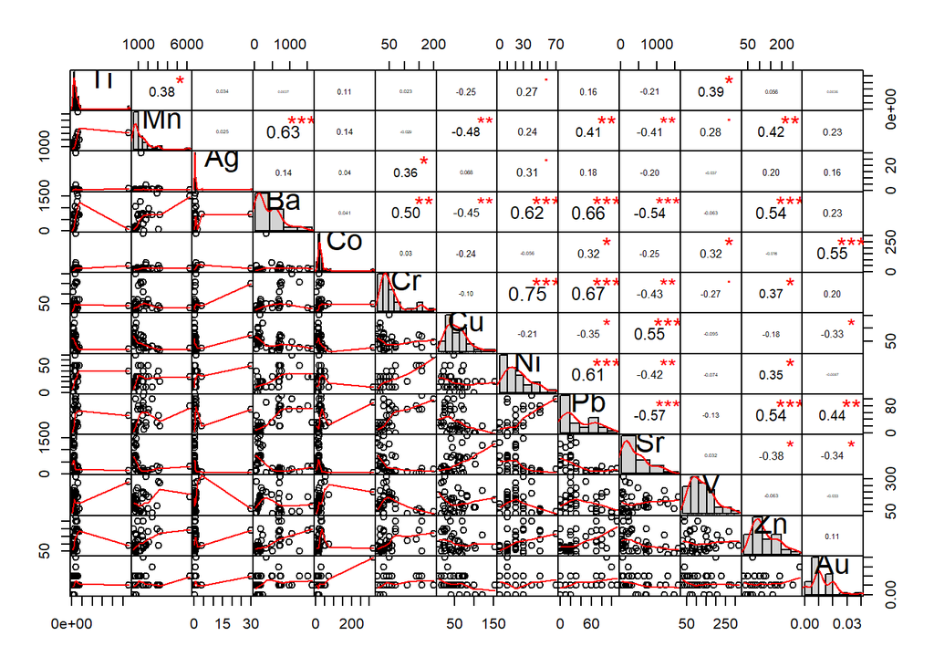

```r
chart.Correlation(X, histogram = TRUE, pch="*", method = c("spearman"), bg=metalicos$Group, pch="+")
```

# Detección de Outliers Multi-variables

```r
par(mfrow = c(1, 2))
# Distancia de Mahalanobis
outliers <- mvn(data = X, multivariateOutlierMethod = "quan")

# Distancia ajustada de Mahalanobis
outliers.adj <- mvn(data = X, multivariateOutlierMethod = "adj")
```

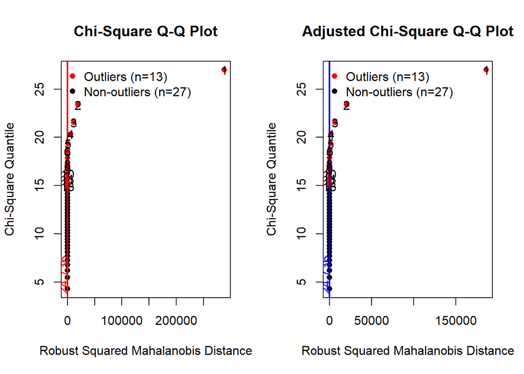

Veamos ahora la normalidad uni-variable a través de gráficos QQ-PLOT.

# Normalidad Uni-variable

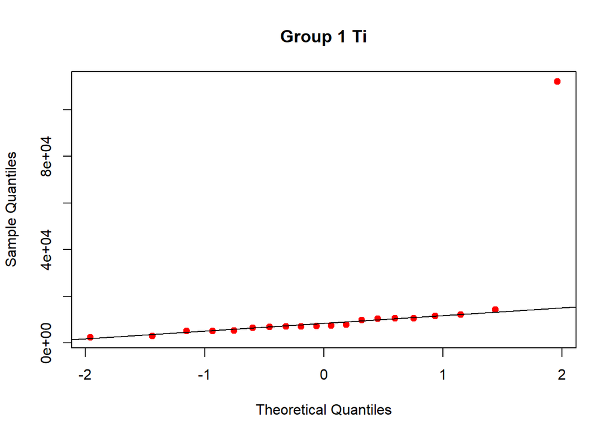

[figure not shown]

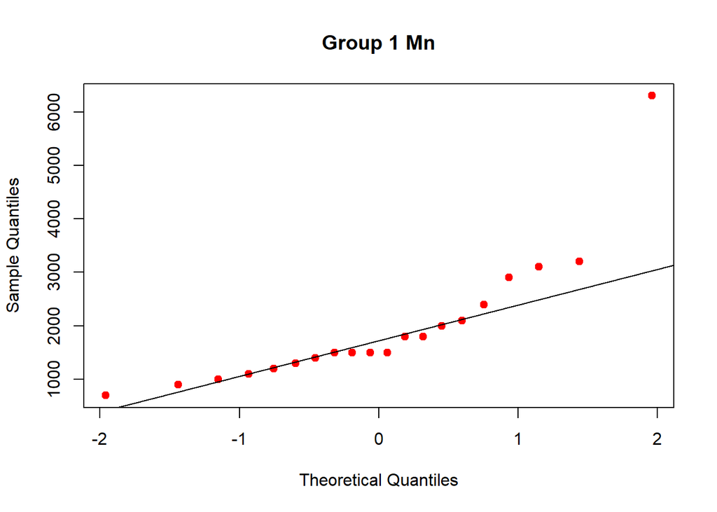

[figure not shown]

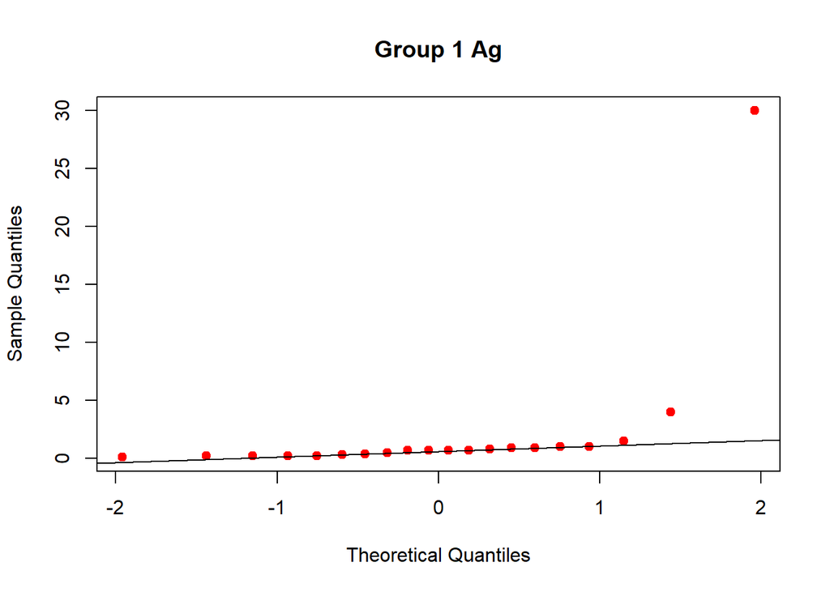

[figure not shown]

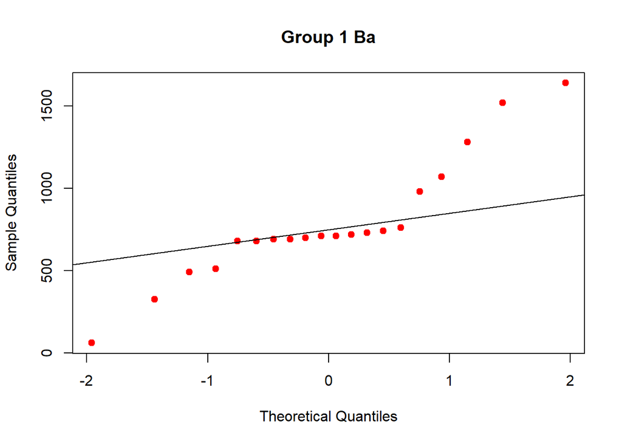

[figure not shown]

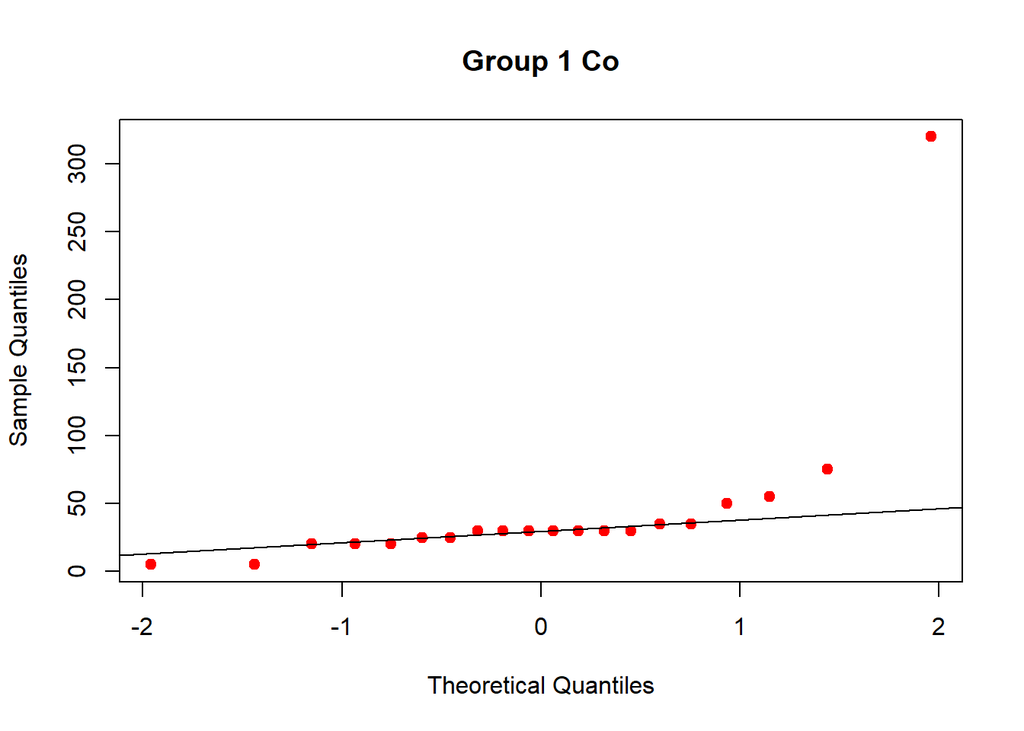

[figure not shown]

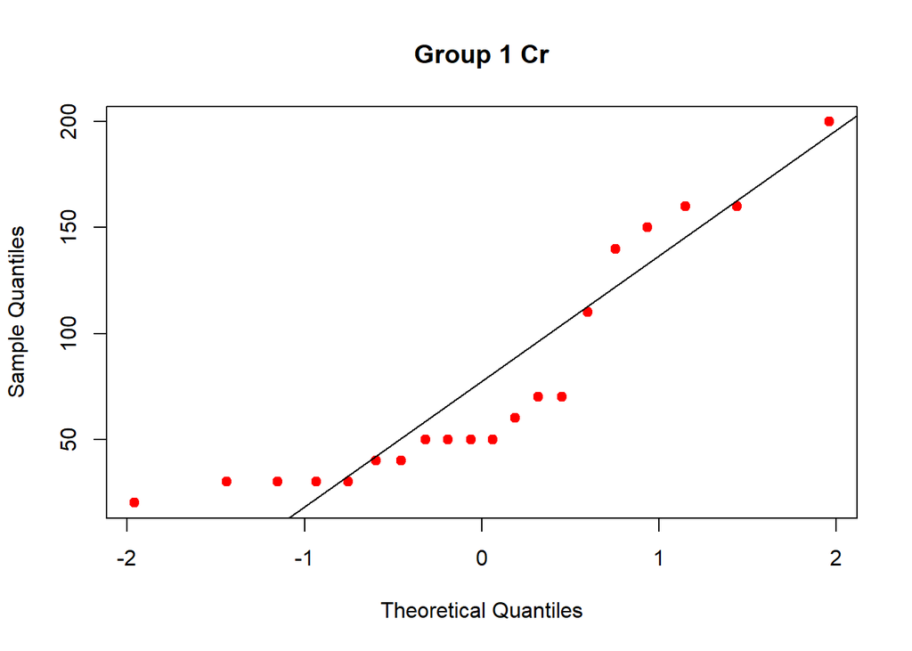

[figure not shown]

[14 more figures not shown]

```r
# QQ-Plot
#par(mfrow=c(4,4))
for (k in 1:13) {
 v <- names(X)[k]
  for (i in 1:2) {
   l <- levels(metalicos$Group)[i]
   x <- metalicos[metalicos$Group==1, v]
qqnorm(x, main = paste("Group", l, v), pch = 19, col = i + 1)
qqline(x)
   }
}
```

Además de la normalidad univariante, se requiere evaluar la normalidad multivariante.

# Normalidad Multi-variable

mvn() -> función del paquete **MVN**, que incluye argumentos para llevar a cabo tests y gráficos de normalidad multivariante, detección de outliers multivariantes, tests y gráficos de normalidad univariante.

La presencia de valores atípicos puede ser causa de no cumplir esta condición. Por ello, es conveniente verificar si los datos tienen outliers multivariantes (valores extremos para combinaciones de variables) antes de comenzar con el análisis multivariante. Con el paquete MVN podemos evaluar la normalidad multivariante con tres de los test comúnmente utilizados, como el de Mardia, Royston y Henze-Zirkler, así como identificar los outliers multivariantes que puedan influir en el contraste.

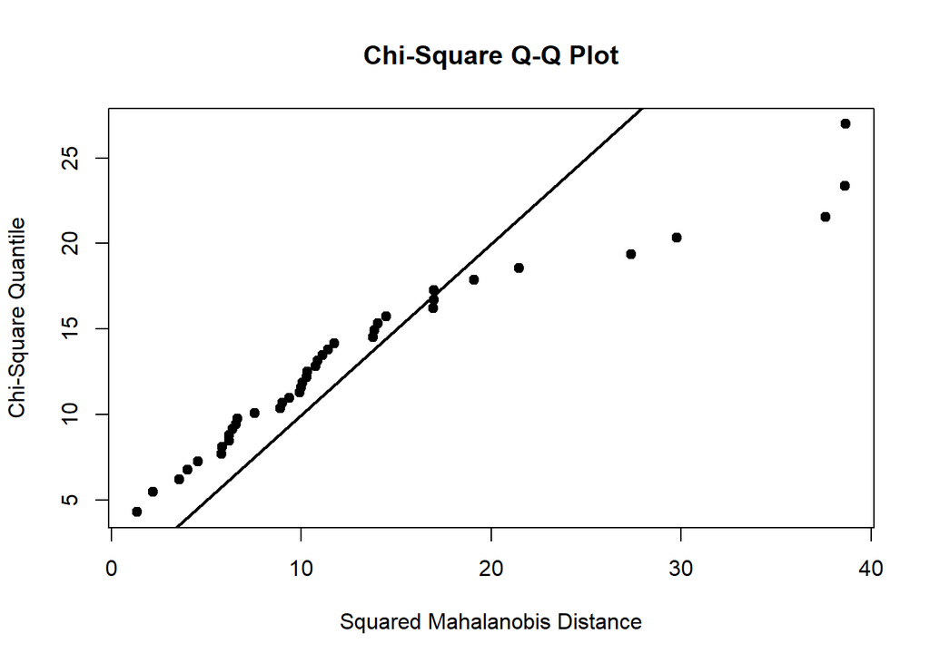

```r
# **Test MVN de Royston**. Nota: no se aconseja usar este test si los datos cuentan con más de 5000 o menos de 3 observaciones, ya que depende del test de Shapiro Wilk.
royston <- mvn(data = metalicos[, -14], mvnTest = "royston", multivariatePlot = "qq")
```

```r
royston
```

```
## $multivariateNormality
##      Test        H      p value MVN
## 1 Royston 282.6437 3.739881e-53  NO
##
## $univariateNormality
##            Test  Variable Statistic   p value Normality
## 1  Shapiro-Wilk    Ti        0.2965  <0.001      NO
## 2  Shapiro-Wilk    Mn        0.7031  <0.001      NO
## 3  Shapiro-Wilk    Ag        0.2187  <0.001      NO
## 4  Shapiro-Wilk    Ba        0.8322  <0.001      NO
## 5  Shapiro-Wilk    Co        0.3516  <0.001      NO
## 6  Shapiro-Wilk    Cr        0.7598  <0.001      NO
## 7  Shapiro-Wilk    Cu        0.9158  0.0057      NO
## 8  Shapiro-Wilk    Ni        0.9140   0.005      NO
## 9  Shapiro-Wilk    Pb        0.8859   8e-04      NO
## 10 Shapiro-Wilk    Sr        0.8618   2e-04      NO
## 11 Shapiro-Wilk     V        0.9305  0.0167      NO
## 12 Shapiro-Wilk    Zn        0.8981  0.0017      NO
## 13 Shapiro-Wilk    Au        0.8453   1e-04      NO
##
## $Descriptives
##     n       Mean      Std.Dev  Median   Min      Max     25th    75th
## Ti 40 8111.75000 1.717009e+04 4905.00 890.0 1.12e+05 2975.000 7335.00
## Mn 40 1330.00000 1.090330e+03  900.00 500.0 6.30e+03  700.000 1525.00
## Ag 40    1.21250 4.715125e+00    0.20   0.1 3.00e+01    0.175    0.70
## Ba 40  449.90000 4.273285e+02  205.00  20.0 1.64e+03  100.000  710.00
## Co 40   30.37500 4.887697e+01   20.00   5.0 3.20e+02   15.000   30.00
## Cr 40   52.00000 4.745848e+01   30.00  10.0 2.00e+02   20.000   60.00
## Cu 40   52.05000 3.100451e+01   46.50   8.0 1.54e+02   25.000   67.50
## Ni 40   22.75000 1.632797e+01   20.00   0.0 7.00e+01   10.000   30.00
## Pb 40   38.00000 3.329742e+01   25.00   0.0 1.10e+02   10.000   70.00
## Sr 40  479.00000 4.367761e+02  320.00  30.0 1.58e+03  127.500  720.00
## V  40  122.25000 7.276543e+01  110.00  30.0 3.20e+02   70.000  160.00
## Zn 40  113.25000 6.517776e+01   90.00  30.0 2.80e+02   67.500  162.50
## Au 40    0.01225 8.619447e-03    0.01   0.0 4.00e-02    0.010    0.02
##         Skew     Kurtosis
## Ti 5.5228962 30.511480701
## Mn 2.5868966  8.412260403
## Ag 5.6873554 31.740893353
## Ba 1.0299401  0.280691673
## Co 5.2011085 27.851999056
## Cr 1.6130060  1.636401001
## Cu 1.1096100  1.295539938
## Ni 0.7718030  0.108480445
## Pb 0.5849267 -1.035158663
## Sr 0.9483330 -0.183585676
## V  0.7969996 -0.001735495
## Zn 0.8525465 -0.321122468
## Au 0.7412094  1.031389931
```

```r
# Test MVN de Henze-Zirkler
hz <- mvn(data = metalicos[, -14], mvnTest = "hz")
hz$multivariateNormality
```

```
##            Test       HZ p value MVN
## 1 Henze-Zirkler 1.109064       0  NO
```

Ambos test confirman que no se cumple la condicion de Normalidad Multi-variable. Esto debe ser tenido en cuenta al evaluar el performance de las predicciones de nuestro modelo.

Ahora realizaremos la prueba de igualdad de medias de los grupos: Test de Wilks (Ho: las medias de los grupos son iguales).

# Test de Igualdad de Medias

Tabla de ANOVA con estadísticos F que permiten contrastar la hipótesis de igualdad de medias entre los grupos en cada variable independiente.

```r
group <- as.factor(metalicos[, 14])
Y <- as.matrix(metalicos[, 1:13])

result <- manova(Y ~ group)
test_Wilks <- summary(result, test = "Wilks")
test_Wilks
```

```
##           Df    Wilks approx F num Df den Df    Pr(>F)
## group      1 0.099136   18.174     13     26 8.128e-10 ***
## Residuals 38
## ---
## Signif. codes:  0 '***' 0.001 '**' 0.01 '*' 0.05 '.' 0.1 ' ' 1
```

La prueba de igualdad de medias de los grupos o Test de Wilks, nos muestra que el p-valor o Pr<0.05 (habrá diferencias entre las medias), por lo que se podrá aplicar el análisis discriminante.

¿Qué variable(s) tiene mayor poder discriminatorio? La variable(s) que mayor poder discriminante tiene es la que tiene menor Pr (p.valor) o mayor F value. Veamos:

# Poder Discriminatorio

```r
poder_discrim <- summary.aov(result)
poder_discrim
```

```
##  Response Ti :
##             Df     Sum Sq   Mean Sq F value  Pr(>F)
## group        1 9.9092e+08 990920702  3.5839 0.06598 .
## Residuals   38 1.0507e+10 276493307
## ---
## Signif. codes:  0 '***' 0.001 '**' 0.01 '*' 0.05 '.' 0.1 ' ' 1
##
##  Response Mn :
##             Df   Sum Sq  Mean Sq F value    Pr(>F)
## group        1 15876000 15876000  19.788 7.312e-05 ***
## Residuals   38 30488000   802316
## ---
## Signif. codes:  0 '***' 0.001 '**' 0.01 '*' 0.05 '.' 0.1 ' ' 1
##
##  Response Ag :
##             Df Sum Sq Mean Sq F value Pr(>F)
## group        1  43.06  43.056  1.9856 0.1669
## Residuals   38 824.01  21.684
##
##  Response Ba :
##             Df  Sum Sq Mean Sq F value    Pr(>F)
## group        1 4472934 4472934  64.168 1.104e-09 ***
## Residuals   38 2648841   69706
## ---
## Signif. codes:  0 '***' 0.001 '**' 0.01 '*' 0.05 '.' 0.1 ' ' 1
##
##  Response Co :
##             Df Sum Sq Mean Sq F value  Pr(>F)
## group        1   8556  8555.6  3.8423 0.05734 .
## Residuals   38  84614  2226.7
## ---
## Signif. codes:  0 '***' 0.001 '**' 0.01 '*' 0.05 '.' 0.1 ' ' 1
##
##  Response Cr :
##             Df Sum Sq Mean Sq F value    Pr(>F)
## group        1  25000 25000.0  15.118 0.0003929 ***
## Residuals   38  62840  1653.7
## ---
## Signif. codes:  0 '***' 0.001 '**' 0.01 '*' 0.05 '.' 0.1 ' ' 1
##
```

[output cut: 31 more lines]

```
## Residuals   38 205395  5405.1
##
##  Response Zn :
##             Df Sum Sq Mean Sq F value    Pr(>F)
## group        1  45562   45562  14.414 0.0005137 ***
## Residuals   38 120115    3161
## ---
## Signif. codes:  0 '***' 0.001 '**' 0.01 '*' 0.05 '.' 0.1 ' ' 1
##
##  Response Au :
##             Df    Sum Sq   Mean Sq F value  Pr(>F)
## group        1 0.0004225 4.225e-04  6.4869 0.01504 *
## Residuals   38 0.0024750 6.513e-05
## ---
## Signif. codes:  0 '***' 0.001 '**' 0.01 '*' 0.05 '.' 0.1 ' ' 1
```

¿Cómo clasifica la función discriminante los datos clasificados inicialmente?

# Fisher Discriminant Functions

```r
fit.lda <- lda(formula = group ~ Ba+Pb, data = X)
fit.lda
```

```
## Call:
## lda(group ~ Ba + Pb, data = X)
##
## Prior probabilities of groups:
##   1   2
## 0.5 0.5
##
## Group means:
##      Ba Pb
## 1 784.3 64
## 2 115.5 12
##
## Coefficients of linear discriminants:
##             LD1
## Ba -0.002579419
## Pb -0.032756538
```

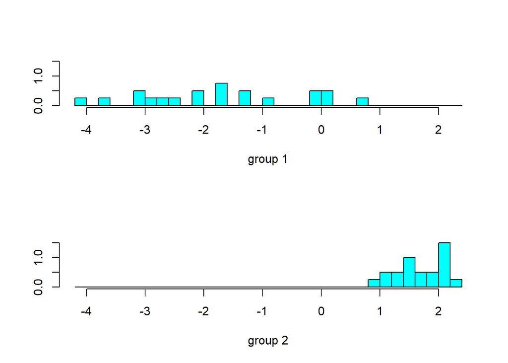

```r
plot(fit.lda)
```

```r
predictions <- predict(fit.lda, X)
table(group, predictions$class)
```

```
##
## group  1  2
##     1 17  3
##     2  0 20
```

```r
#ldahist(data = predictions$x[,1], g=metalicos$Group, nbins = 25)
```

El modelo calcula automáticamente las probabilidades a priori (π0 = 0,5, π1 = 0,5), y el promedio de cada predictor dentro de cada clase, usados por el modelo como estimadores de µk. Los coeficientes proporcionan la combinación de los predictores para generar los discriminantes lineales para cada una de las observaciones de entrenamiento.

La función discriminante clasifica los datos conocidos o clasificados inicialmente, proporcionándonos una idea de la calidad de la función discriminante. Los resultados muestran que la función discriminante clasifica los 20 casos del grupo 1 en 17 casos en el grupo 1 y 3 en el grupo 2; mientras que los 20 casos del grupo 2 son clasificados correctamente en el grupo 2.

El modelo es capaz de clasificar correctamente (17+20)/(17+20+0+3)=0.925 (92.5%) de las observaciones cuando se emplean los datos completos.

La función discriminante lineal de Fisher se define como:

$$D - C = A1*X1 + A2*X2 - C$$

Notese que R no arroja el valor de la constante (C), esto es debido a que de forma predeterminada, la función R ‘lda’ del paquete MASS, centra los datos. Para obtener la constante utilizaremos el siguiente código:

```r
groupmean <- (fit.lda$prior %*% fit.lda$means)
constant <- (groupmean %*% fit.lda$scaling)
constant
```

```
##            LD1
## [1,] -2.405229
```

Utilizando los valores de los coeficientes sin estádarizar de las funciones canónicas y la constante, podemos construir la función discriminante, como:

$$D - C = -0.00258*Ba - 0.03276*Pb - 2.4052$$

# Clasificación de los nuevos casos:

```r
lda.pred1 <- predict(fit.lda, clasificar)
newcases <- lda.pred1$class
newcases
```

```
## [1] 2 2 1 2 2 2
## Levels: 1 2
```

```r
# Aplicando un threshold del 50% a las probabilidades a posterior podemos recrear las predicciones del modelo
sum(lda.pred1$posterior[, 1] >= 0.5)
```

```
## [1] 1
```

```r
sum(lda.pred1$posterior[,1] < 0.5)
```

```
## [1] 5
```

La función predict() ha calculado las probabilidades a posteriori de que cada nueva observación pertenezca a uno de los grupos. Es decir, la muestra 1, 2, 4, 5 y 6 pertenecen al grupo 2, mientras que la muestra 3 la clasifica en el grupo 1.

# Solution Exercise 2: LDA - Using Caret package

El primer paso, activar el paquete caret. Luego, crea el resultado de predicción usando la función **train()**. Usaremos la función **confusionMatrix()** para ver la precisión de la predicción del modelo.

Dado que hay pocos datos, se utilizará la data completa y la técnica de Validación Cruzada (CV).

```r
fitControl <- trainControl(# 10-fold CV
                           method = "repeatedcv",
                           number = 10,                         # number of folds
                           repeats = 3,
                           allowParallel = TRUE                 # Parallel processing
                           )

# LDA
fit.lda.cv <- train(Group ~ Ba+Pb,
                data = metalicos,
                #preProc = c("center", "scale"),
                #method = "stepLDA",
                method = "lda",
                metric = "Accuracy",                            # Specify which metric to optimize
                trControl = fitControl
                )

print(fit.lda.cv)
```

```
## Linear Discriminant Analysis
##
## 40 samples
##  2 predictor
##  2 classes: '1', '2'
##
## No pre-processing
## Resampling: Cross-Validated (10 fold, repeated 3 times)
## Summary of sample sizes: 36, 36, 36, 36, 36, 36, ...
## Resampling results:
##
##   Accuracy   Kappa
##   0.8833333  0.7666667
```

```r
fit.lda.cv$finalModel
```

```
## Call:
## lda(x, grouping = y)
##
## Prior probabilities of groups:
##   1   2
## 0.5 0.5
##
## Group means:
##      Ba Pb
## 1 784.3 64
## 2 115.5 12
##
## Coefficients of linear discriminants:
##             LD1
## Ba -0.002579419
## Pb -0.032756538
```

Utilizando los valores de los coeficientes estándarizados de las funciones canónicas, podemos construir la función discriminante final, como:

$$F = -0.00257*Ba - 0.03276*Pb - (-2.4052)$$

$$F = -0.00257*Ba - 0.03276*Pb + 2.4052$$

Interpretación: si el valor de F < 0, entonces, la muestra pertenece al grupo X1; si el valor de F > 0, entonces, la muestra pertenece al grupo X2. Por ejemplo, si caracterizamos una muestra de agua de los drenajes superficiales y el porcentaje de Ba es 630 ppm y el porcentaje de Pb es de 90 ppm, ésta pertenecería al Grupo X1, debido a que F < 0.

# Clasificación de los nuevos casos:

```r
lda.pred2 <- predict(fit.lda.cv, clasificar)
lda.pred2
```

```
## [1] 2 2 1 2 2 2
## Levels: 1 2
```

Es decir, la muestra 3 pertenece al grupo 1, mientras que las cinco restantes pertenecen al grupo 2.

# Visualization 1

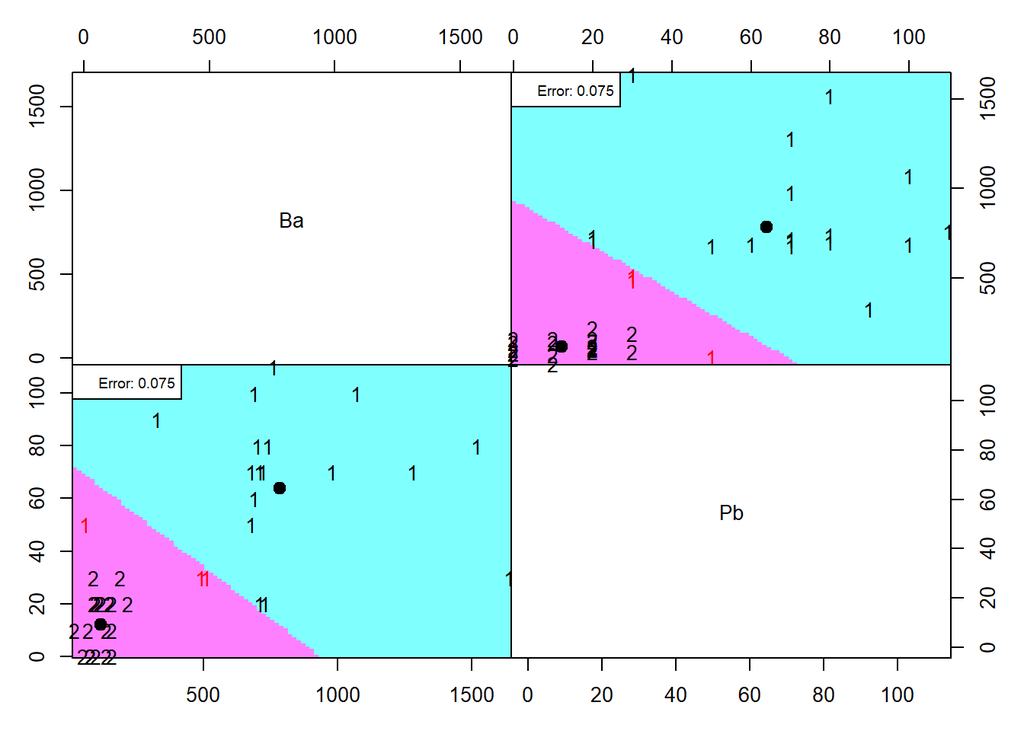

```r
partimat(Group ~ Ba+Pb, data = metalicos, method = "lda", plot.matrix = T, imageplot = T, main = "Partition Plot") #image.colors = c("darkgoldenrod1","skyblue2"))
```

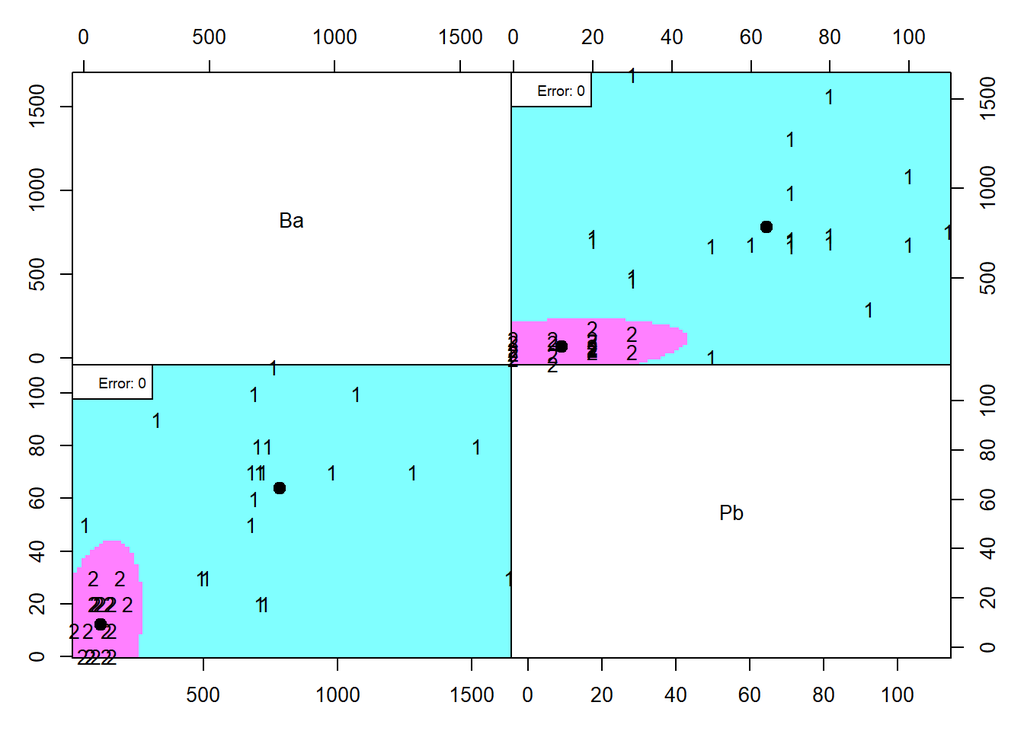

```r
partimat(Group ~ Ba+Pb, data = metalicos, method = "qda", plot.matrix = T, imageplot = T, main = "Partition Plot") #image.colors = c("darkgoldenrod1","skyblue2"),)
```

LDA es un método mucho menos flexible que QDA y sufre de menos varianza. Ello puede suponer una mejora en la predicción, pero hay un inconveniente: si la asunción del LDA de que todas las clases comparten la misma matriz de covarianza no es correcta en realidad, el LDA puede sufrir un alto bias o sesgo. Visto de otra manera, LDA suele ser mejor que QDA si contamos con relativamente pocas observaciones de entrenamiento y reducir la varianza es importante. Por el contrario, se recomienda QDA si el set de observaciones de entrenamiento es muy grande y la varianza del clasificador no supone un problema, o si el supuesto de una matriz de covarianza común entre las clases claramente no se cumple.

```
 Si el verdadero límite de Bayes es lineal, LDA será una aproximación más precisa que QDA. Si por el contrario no es lineal, QDA será una mejor opción.
```

# Visualization 2

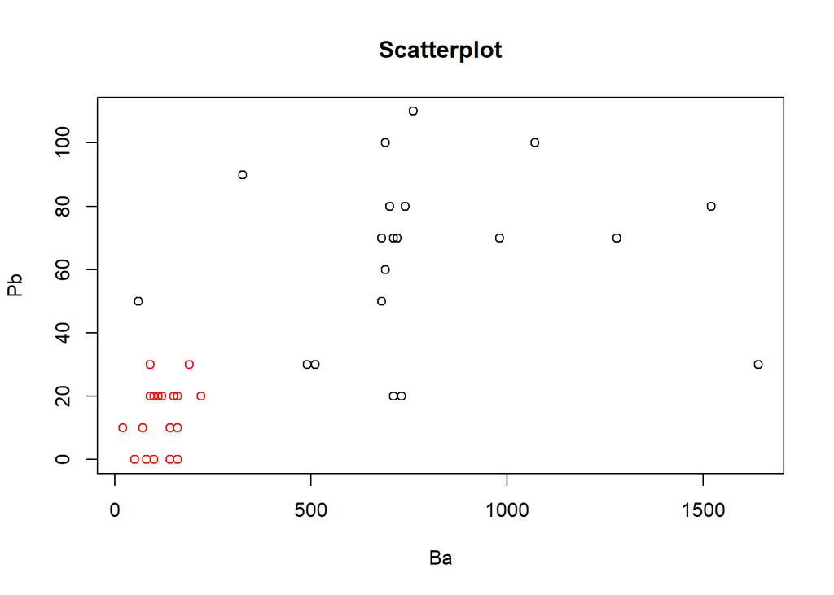

```r
# decisionplot function
# source: http://michael.hahsler.net/SMU/EMIS7332/R/viz_classifier.html

decisionplot <- function(model, data, class = NULL, predict_type = "class",
  resolution = 100, showgrid = TRUE, ...) {

  if(!is.null(class)) cl <- data[,class] else cl <- 1
  data <- data[,1:2]
  k <- length(unique(cl))

  plot(data, col = as.integer(cl)+1L, pch = as.integer(cl)+1L, ...)

  # make grid
  r <- sapply(data, range, na.rm = TRUE)
  xs <- seq(r[1,1], r[2,1], length.out = resolution)
  ys <- seq(r[1,2], r[2,2], length.out = resolution)
  g <- cbind(rep(xs, each=resolution), rep(ys, time = resolution))
  colnames(g) <- colnames(r)
  g <- as.data.frame(g)

  ### guess how to get class labels from predict
  ### (unfortunately not very consistent between models)
  p <- predict(model, g, type = predict_type)
  if(is.list(p)) p <- p$class
  p <- as.factor(p)

  if(showgrid) points(g, col = as.integer(p)+1L, pch = ".")

  z <- matrix(as.integer(p), nrow = resolution, byrow = TRUE)
  contour(xs, ys, z, add = TRUE, drawlabels = FALSE,
    lwd = 2, levels = (1:(k-1))+.5)

  invisible(z)
}


# Data Subset
rain_df.sub <- subset(metalicos, select=c(Ba, Pb, Group))

# Plot XY
plot(rain_df.sub[, 1:2], col = rain_df.sub[, 3], main = "Scatterplot")
```

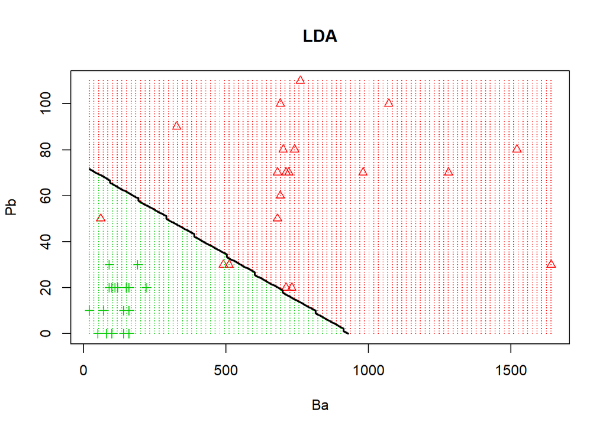

```r
fit.lda.boundary <- lda(formula = group ~ Ba+Pb, data = X)
decisionplot(fit.lda.boundary, rain_df.sub, class = "Group", main = "LDA")
```

# Logistic Regression

```r
model.lr <- glm(formula = Group ~ Ba+Pb, data = metalicos, family = binomial(link='logit'))
```

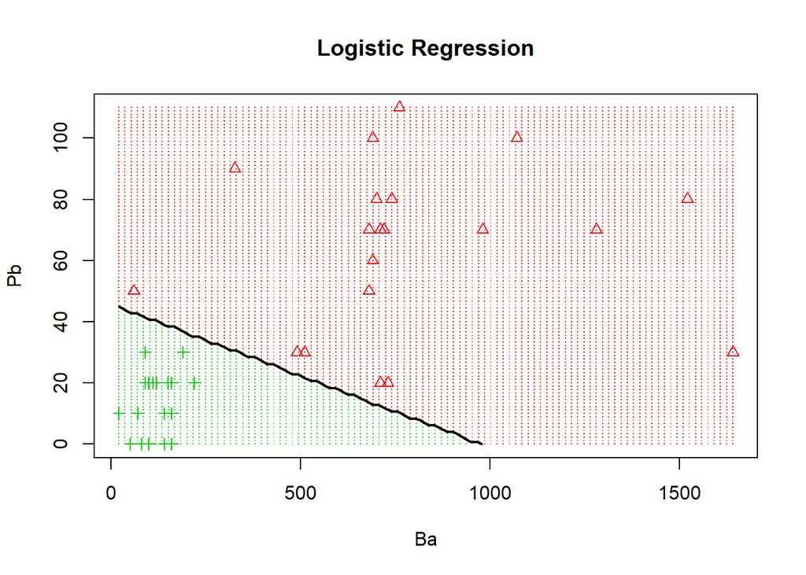

```r
class(model.lr) <- c("lr", class(model.lr))
predict.lr <- function(object, newdata, ...)
  predict.glm(object, newdata, type = "response") > .5

decisionplot(model.lr, rain_df.sub, class = "Group", main = "Logistic Regression")
```

## Help

https://web.ua.es/es/lpa/docencia/analisis-estadistico-de-datos-geoquimicos-con-r/analisis-discriminante.html https://rstudio-pubs-static.s3.amazonaws.com/277311_5cb3270d086b41aa92e4a7aa750dba54.html https://little-book-of-r-for-multivariate-analysis.readthedocs.io/en/latest/src/multivariateanalysis.html http://michael.hahsler.net/SMU/EMIS7332/R/viz_classifier.html#linear-discriminant-analysis https://rpubs.com/Cristina_Gil